# CME 250 HW

Anna Khazenzon

January 13, 2015

# Conceptual Exercises

## (Introduction) section 2.4

### Question 1

#### Part a

If the sample size n is extremely large, and the number of predictors p is small, we would expect a flexible method to work better. A flexible method is unlikely to overfit the data with a large n, and would instead better fit the data than an inflexible model would.

#### Part b

If the number of predictors p is extremely large, and the number of observations is small, we would expect an inflexible method to work better. A flexible method would likely overfit the data.

#### Part c

If the relationship between the predictors and response is highly non-linear, we would expect a flexible method to work better. Flexible methods are able to reveal more complex shapes than inflexible methods (such as linear regression).

#### Part d

If the variance of the error terms, i.e. σ2 = Var(), is extremely high, we would expect an inflexible method to work better. A flexible method would be likely to follow the errors too closely, and thus overfit the data.

### Question 2

Explain whether each scenario is a classification or regression problem, and indicate whether we are most interested in inference or prediction. Finally, provide n and p.

#### Part a

1. We collect a set of data on the top 500 firms in the US. For each firm we record profit, number of employees, industry and the CEO salary. We are interested in understanding which factors affect CEO salary.

Regression, inference

n=500 (top firms) p=3 (profit, number of employes, industry)

#### Part b

2. We are considering launching a new product and wish to know whether it will be a success or a failure. We collect data on 20 similar products that were previously launched. For each product we have recorded whether it was a success or failure, price charged for the product, marketing budget, competition price, and ten other variables.

Classification, prediction

n=20 (similar products) p=13 (price charged, marketing budget, competition price, +10)

#### Part c

3. We are interested in predicting the % change in the US dollar in relation to the weekly changes in the world stock markets. Hence we collect weekly data for all of 2012. For each week we record the % change in the dollar, the % change in the US market, the % change in the British market, and the % change in the German market.

Regression, prediction

n=52 (weeks) p=3 (% change in dollar, % change in US market, % change in British market, % change in German market)

### Question 6

Describe the differences between a parametric and a non-parametric statistical learning approach. What are the advantages of a parametric approach to regression or classification (as opposed to a nonparametric approach)? What are its disadvantages?

A parametric statistical learning approach involves constructing a model that can be parameterized by a finite number of parameters. Parametric procedures rely on assumptions about the shape of the distribution in the underlying population, and about the form, or parameters, of the assumed distribution. On the other hand, a nonparametric model cannot be parameterized by a fixed number of parameters.

An advantage of nonparametric methods over parametric is that they can handle nonnormal data, because they do not rely on assumptions about the shape or form of the probability distribution from which the data are drawn. Using a parametric approach to analyze data which do not meet underlying assumptions can lead to misleading results.

A disadvantage of nonparametric approaches is that they can be less powerful than their paramatric counterparts when the data truly are normally distributed, so there is greater incidence of Type II errors, or false negatives. A larger sample size will be necessary to rectify this issue. Another disadvantage is that results can be more difficult to interpret.

More specifically, parametric statistical learning approaches involve a two-step model-based approach: first we make an assumption about the shape of the function $f$ to select a model, then we use training data to fit the model. This approach is called parametric because it reduces the problem of estimating the function down to one of estimating a set of parameters. An advantage of this approach is that it simplifies the problem of estimating $f$ with a set of parameters, rather than fitting an entirely arbitrary $f$. The disadvantage is that the model we choose might not match the true unknown form of $f$. To ameliorate this problem, we might fit a more flexible model, but this may lead to overfitting of the data (ie following the noise in the data too closely).

Nonparametric statistical learning approaches do not make explicit assumptions about the functional form of $f$, but rather seek an estimate for $f$ that is reasonably close. Without relying on assumptions, nonparametric approaches can accurately fit a wider range of possible shapes for $f$.

## (Linear Regression) section 3.7

### Question 3

Suppose we have a data set with five predictors, X1 = GPA, X2 = IQ, X3 = Gender (1 for Female and 0 for Male), X4 = Interaction between GPA and IQ, and X5 = Interaction between GPA and Gender. The response is starting salary after graduation (in thousands of dollars). Suppose we use least squares to fit the model, and get βˆ0 = 50, βˆ1 = 20, βˆ2 = 0.07, βˆ3 = 35, βˆ4 = 0.01, βˆ5 = −10. (a) Which answer is correct, and why? i. For a fixed value of IQ and GPA, males earn more on average than females. ii. For a fixed value of IQ and GPA, females earn more on average than males. iii. For a fixed value of IQ and GPA, males earn more on average than females provided that the GPA is high enough. iv. For a fixed value of IQ and GPA, females earn more on average than males provided that the GPA is high enough. (b) Predict the salary of a female with IQ of 110 and a GPA of 4.0.

#### Part a

3. For a fixed value of IQ and GPA, males earn more on average than females provided that the GPA is high enough.

Even with a fixed value of IQ and GPA, because of the interaction effect between GPA and gender, males earn more on average than females at a high GPA, eg a 4.0.

#### Part b

$y = 50 + 20*4 + .07*110 + 35*1 + .01*110*4 + (-10)*4*1 = 137.1$

The predicted starting salary for a female with IQ 110 and GPA 4.0 is $137,100.

## (Logistic Regression) section 4.7

### Question 8

Suppose that we take a data set, divide it into equally-sized training and test sets, and then try out two different classification procedures. First we use logistic regression and get an error rate of 20 % on the training data and 30 % on the test data. Next we use 1-nearest neighbors (i.e. K = 1) and get an average error rate (averaged over both test and training data sets) of 18 %. Based on these results, which method should we prefer to use for classification of new observations? Why?

Based on these results, we should prefer to use logistic regression for classification. Even though 1-nearest neighbors has a lower average error rate than either training or test error rates for logistic regression, this is misleading, because 1-nearest neighbors is drastically overfitting the data. It is unlikely that it would do well on a training set. The classifier likely had 0% error at training, and 36% error at test, because the decision boundary is fit closely to every single data point, and would not generalize well to other data.

## (Regularization) section 6.8

### Question 2

indicate which of i. through iv. is correct. Justify your answer. (a) The lasso, relative to least squares, is:

1. More flexible and hence will give improved prediction accuracy when its increase in bias is less than its decrease in variance.
2. More flexible and hence will give improved prediction accuracy when its increase in variance is less than its decrease in bias.
3. Less flexible and hence will give improved prediction accuracy when its increase in bias is less than its decrease in variance.
4. Less flexible and hence will give improved prediction accuracy when its increase in variance is less than its decrease in bias.

#### Part a

The lasso, relative to least squares, is less flexible and hence will give improved prediction accuracy when its increase in bias is less than its decrease in variance.

#### Part b

Ridge regression, relative to least squares, is less flexible and hence will give improved prediction accuracy when its increase in bias is less than its decrease in variance.

## (Clustering) section 10.7

### Question 3

## (Cross-validation) section 5.4

### Question 3

LOOCV = leave one out cross val

## (Trees, CART) section 8.4

### Question 4

## (SVM) section 9.7

### Question 3

# Applied Exercises

```r
library(ggplot2)
```

## (Introduction) section 2.4

### Question 9

#### Part a

```r
a <- read.csv("http://www-bcf.usc.edu/~gareth/ISL/Auto.csv", header=T)
```

Quantitative parts of the predictors: mpg, cylinders(?), displacement, weight, acceleration, year(?) Qualitative parts of the predictors: origin(?), name, horsepower(?)

#### Part b

Range of quantitative predictors:

```r
summary(a)
```

```
##       mpg          cylinders      displacement     horsepower
##  Min.   : 9.00   Min.   :3.000   Min.   : 68.0   150    : 22
##  1st Qu.:17.50   1st Qu.:4.000   1st Qu.:104.0   90     : 20
##  Median :23.00   Median :4.000   Median :146.0   88     : 19
##  Mean   :23.52   Mean   :5.458   Mean   :193.5   110    : 18
##  3rd Qu.:29.00   3rd Qu.:8.000   3rd Qu.:262.0   100    : 17
##  Max.   :46.60   Max.   :8.000   Max.   :455.0   75     : 14
##                                                  (Other):287
##      weight      acceleration        year           origin
##  Min.   :1613   Min.   : 8.00   Min.   :70.00   Min.   :1.000
##  1st Qu.:2223   1st Qu.:13.80   1st Qu.:73.00   1st Qu.:1.000
##  Median :2800   Median :15.50   Median :76.00   Median :1.000
##  Mean   :2970   Mean   :15.56   Mean   :75.99   Mean   :1.574
##  3rd Qu.:3609   3rd Qu.:17.10   3rd Qu.:79.00   3rd Qu.:2.000
##  Max.   :5140   Max.   :24.80   Max.   :82.00   Max.   :3.000
##
##              name
##  ford pinto    :  6
##  amc matador   :  5
##  ford maverick :  5
##  toyota corolla:  5
##  amc gremlin   :  4
##  amc hornet    :  4
##  (Other)       :368
```

mpg: 9-46.6 cylinders: 3-8 displacement: 68-455 weight: 1613-5140 acceleration: 8-24.8 year: 70-82

#### Part c

Mean and standard deviation of quantitative predictors:

```
## [1] mean mpg:
```

```
## [1] 23.51587
```

```
## [1] mpg sd:
```

```
## [1] 7.825804
```

```
## [1] mean cylinders:
```

```
## [1] 5.458438
```

```
## [1] cylinders sd:
```

```
## [1] 1.701577
```

```
## [1] mean displacement:
```

```
## [1] 193.5327
```

```
## [1] displacement sd:
```

```
## [1] 104.3796
```

```
## [1] mean weight:
```

```
## [1] 2970.262
```

```
## [1] weight sd:
```

```
## [1] 847.9041
```

```
## [1] mean acceleration:
```

```
## [1] 15.55567
```

```
## [1] acceleration sd:
```

```
## [1] 2.749995
```

```
## [1] mean year:
```

```
## [1] 75.99496
```

```
## [1] year sd:
```

```
## [1] 3.690005
```

#### Part d

```r
#remove 10th-85th obs
a_subset <- a[10:85,]

#range & mean
summary(a_subset)
```

```
##       mpg          cylinders      displacement     horsepower
##  Min.   : 9.00   Min.   :3.000   Min.   : 70.0   150    : 6
##  1st Qu.:14.00   1st Qu.:4.000   1st Qu.:109.2   88     : 5
##  Median :19.00   Median :6.000   Median :199.5   90     : 5
##  Mean   :19.62   Mean   :5.829   Mean   :220.9   95     : 5
##  3rd Qu.:25.00   3rd Qu.:8.000   3rd Qu.:323.5   100    : 4
##  Max.   :35.00   Max.   :8.000   Max.   :455.0   175    : 3
##                                                  (Other):48
##      weight      acceleration        year           origin
##  Min.   :1613   Min.   : 8.00   Min.   :70.00   Min.   :1.000
##  1st Qu.:2249   1st Qu.:13.00   1st Qu.:70.00   1st Qu.:1.000
##  Median :2883   Median :14.50   Median :71.00   Median :1.000
##  Mean   :3124   Mean   :14.85   Mean   :71.11   Mean   :1.474
##  3rd Qu.:4106   3rd Qu.:16.50   3rd Qu.:72.00   3rd Qu.:2.000
##  Max.   :5140   Max.   :23.50   Max.   :72.00   Max.   :3.000
##
##                  name
##  amc gremlin       : 2
##  chevrolet impala  : 2
##  datsun pl510      : 2
##  ford galaxie 500  : 2
##  plymouth fury iii : 2
##  amc ambassador dpl: 1
##  (Other)           :65
```

```r
#sd
sd(a_subset$mpg)
```

```
## [1] 6.123108
```

```r
sd(a_subset$cylinders)
```

```
## [1] 1.857512
```

```r
sd(a_subset$displacement)
```

```
## [1] 119.2912
```

```r
sd(a_subset$weight)
```

```
## [1] 981.1961
```

```r
sd(a_subset$acceleration)
```

```
## [1] 2.940544
```

```r
sd(a_subset$year)
```

```
## [1] 0.7929514
```

#### Part e

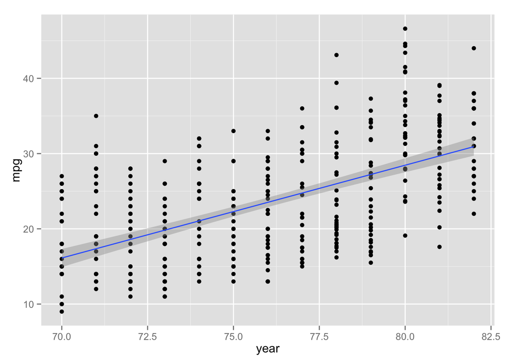

```r
#plot data (scatter)
ggplot(a,aes(x=year,y=mpg)) + geom_point() + stat_smooth(method="lm")
```

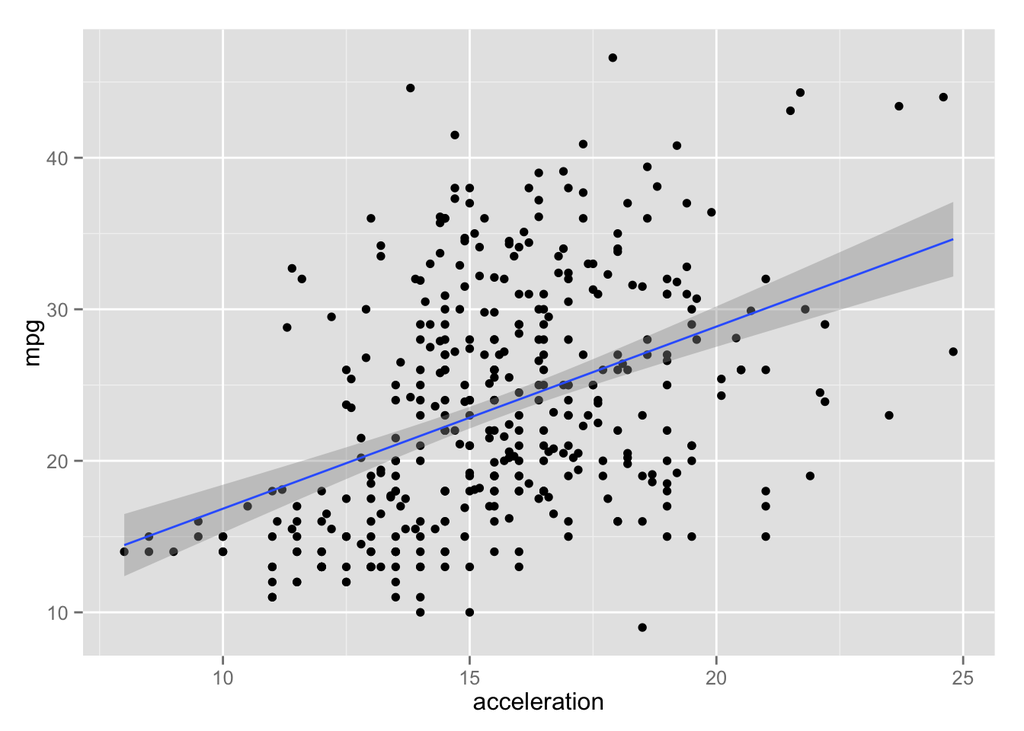

```r
ggplot(a,aes(x=acceleration,y=mpg)) + geom_point() + stat_smooth(method="lm")
```

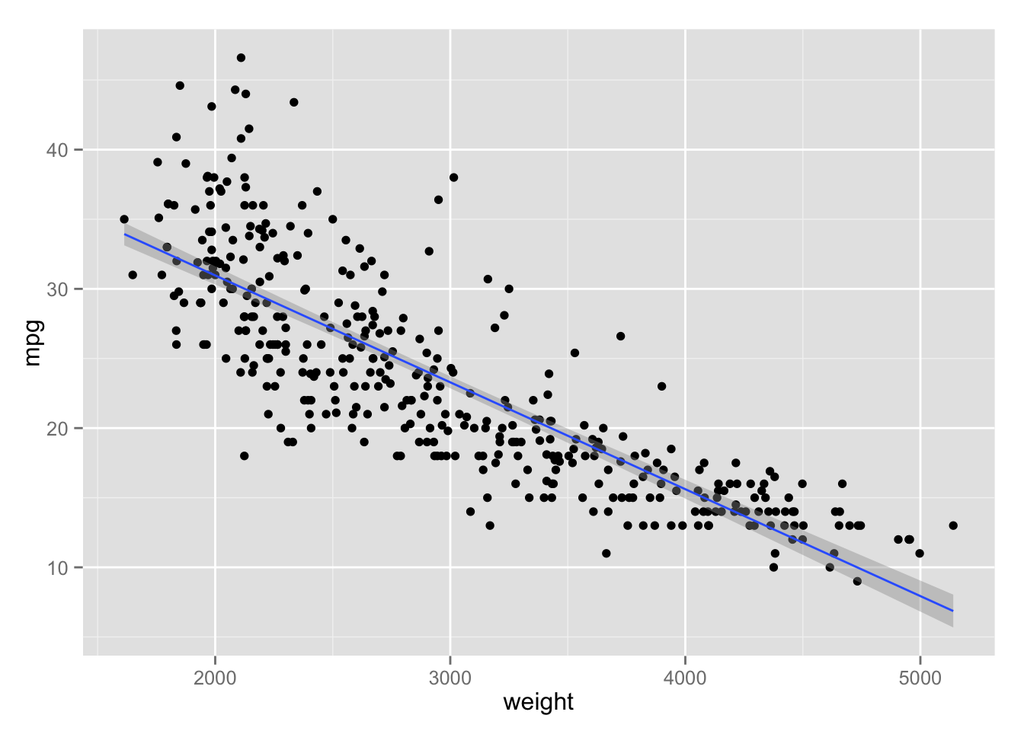

```r
ggplot(a,aes(x=weight,y=mpg)) + geom_point() + stat_smooth(method="lm")
```

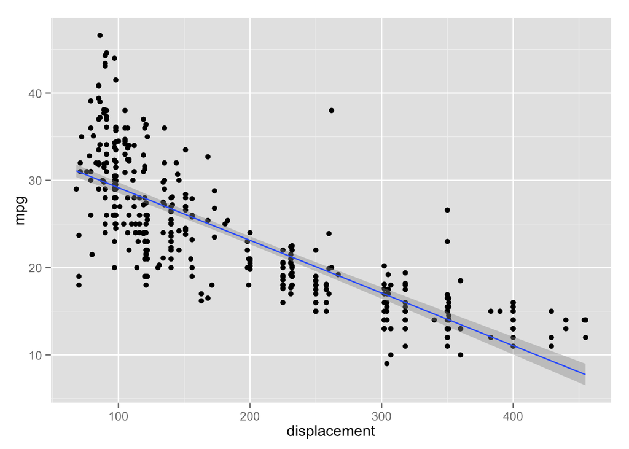

```r
ggplot(a,aes(x=displacement,y=mpg)) + geom_point() + stat_smooth(method="lm")
```

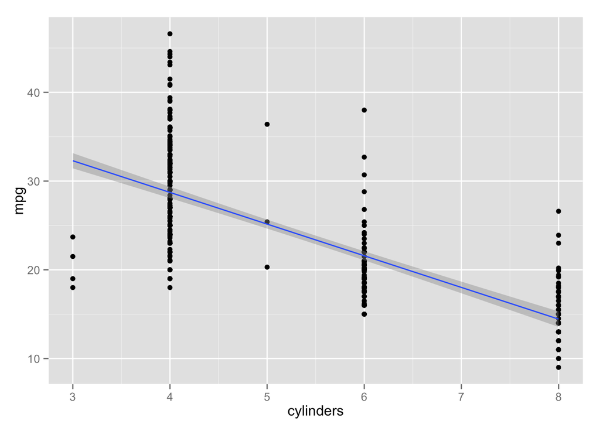

```r
ggplot(a,aes(x=cylinders,y=mpg)) + geom_point() + stat_smooth(method="lm")
```

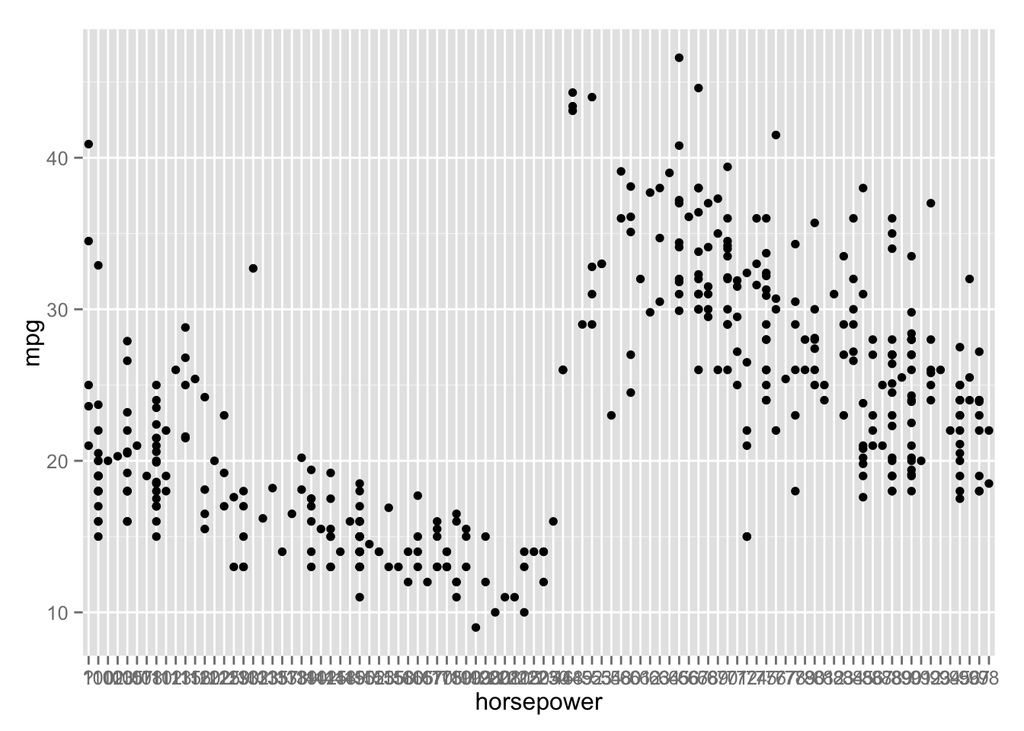

```r
ggplot(a,aes(x=horsepower,y=mpg)) + geom_point()  # what should i do here
```

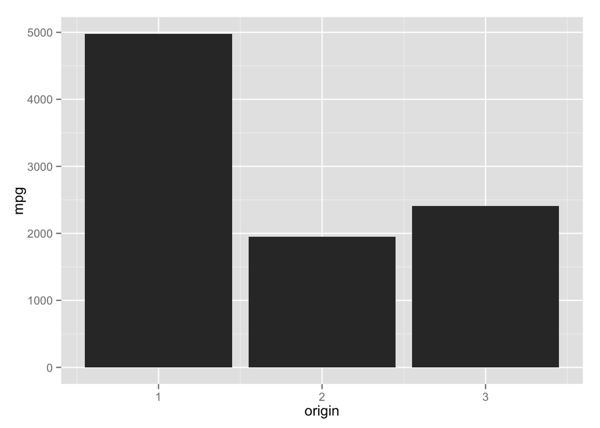

```r
ggplot(a,aes(x=origin,y=mpg)) + geom_bar(stat="identity")
```

#### Part f

The plot of the effect of weight on mpg suggests that heavier cars have lower miles per gallon. This is plausible, since it would take more gasoline to move a heavier car.

## (Linear Regression) section 3.7

### Question 9

5. Use the * and : symbols to fit linear regression models with interaction effects. Do any interactions appear to be statistically significant?
6. Try a few different transformations of the variables, such as log(X), √ X, X2. Comment on your findings.

#### Part a

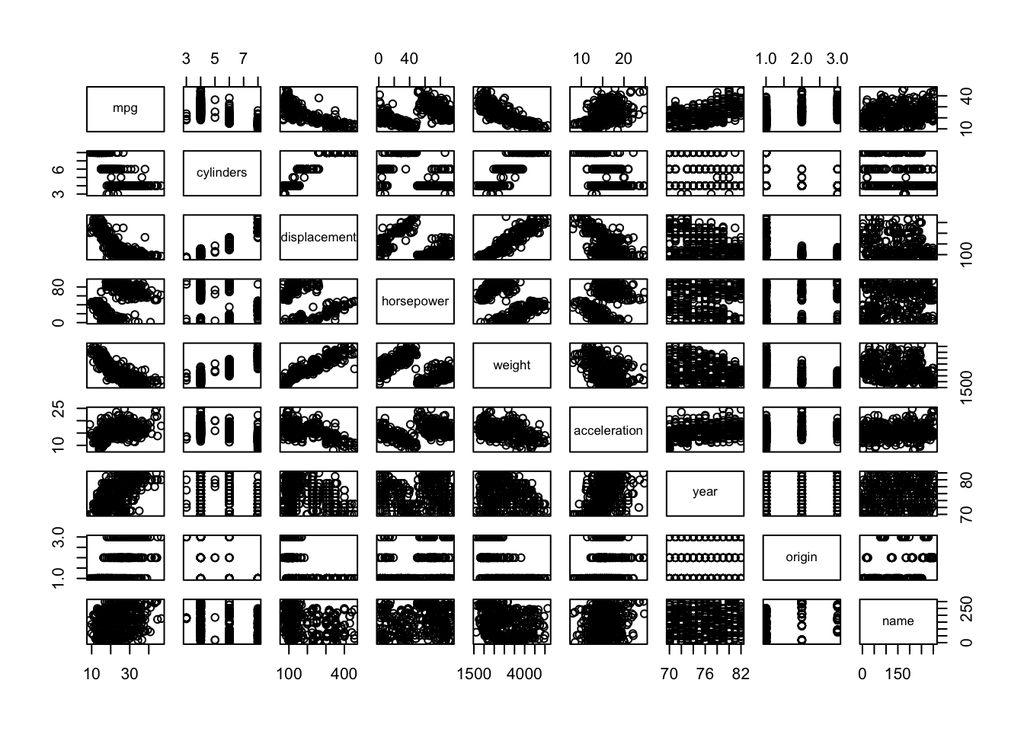

```r
pairs(a)
```

#### Part b

```r
a_num <- a[,1:7]
a_num$horsepower <- as.numeric(a_num$horsepower)
cor(a_num)
```

```
##                     mpg  cylinders displacement horsepower     weight
## mpg           1.0000000 -0.7762599   -0.8044430  0.4228227 -0.8317389
## cylinders    -0.7762599  1.0000000    0.9509199 -0.5466585  0.8970169
## displacement -0.8044430  0.9509199    1.0000000 -0.4820705  0.9331044
## horsepower    0.4228227 -0.5466585   -0.4820705  1.0000000 -0.4821507
## weight       -0.8317389  0.8970169    0.9331044 -0.4821507  1.0000000
## acceleration  0.4222974 -0.5040606   -0.5441618  0.2662877 -0.4195023
## year          0.5814695 -0.3467172   -0.3698041  0.1274167 -0.3079004
##              acceleration       year
## mpg             0.4222974  0.5814695
## cylinders      -0.5040606 -0.3467172
## displacement   -0.5441618 -0.3698041
## horsepower      0.2662877  0.1274167
## weight         -0.4195023 -0.3079004
## acceleration    1.0000000  0.2829009
## year            0.2829009  1.0000000
```

#### Part c

```r
rs <- lm(mpg ~ cylinders + displacement + horsepower + weight + acceleration + year, data=a_num)
summary(rs)
```

```
##
## Call:
## lm(formula = mpg ~ cylinders + displacement + horsepower + weight +
##     acceleration + year, data = a_num)
##
## Residuals:
##     Min      1Q  Median      3Q     Max
## -8.7503 -2.4208 -0.0873  1.9823 14.3087
##
## Coefficients:
##                Estimate Std. Error t value Pr(>|t|)
## (Intercept)  -1.640e+01  4.271e+00  -3.839 0.000144 ***
## cylinders    -1.569e-01  3.473e-01  -0.452 0.651789
## displacement  6.299e-03  7.233e-03   0.871 0.384355
## horsepower    8.980e-03  7.013e-03   1.280 0.201131
## weight       -6.827e-03  5.975e-04 -11.427  < 2e-16 ***
## acceleration  8.384e-02  7.854e-02   1.067 0.286408
## year          7.640e-01  5.085e-02  15.025  < 2e-16 ***
## ---
## Signif. codes:  0 '***' 0.001 '**' 0.01 '*' 0.05 '.' 0.1 ' ' 1
##
## Residual standard error: 3.432 on 390 degrees of freedom
## Multiple R-squared:  0.8106, Adjusted R-squared:  0.8076
## F-statistic: 278.1 on 6 and 390 DF,  p-value: < 2.2e-16
```

There is a significant negative relationship between a car’s weight and its mpg, *t*(390)=-11.43, *p*<.001. Converseley, there is a significant positive relationship between the year a car was made and its mpg, meaning modern cars have higher mpg, *t*(390)=15.025, *p*<.001

#### Part d

4. Use the plot() function to produce diagnostic plots of the linear regression fit. Comment on any problems you see with the fit. Do the residual plots suggest any unusually large outliers? Does the leverage plot identify any observations with unusually high leverage?

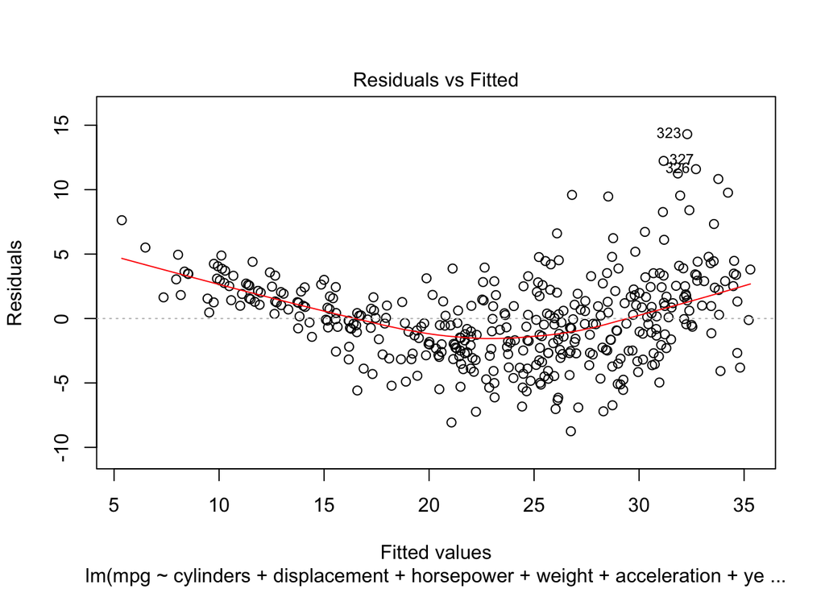

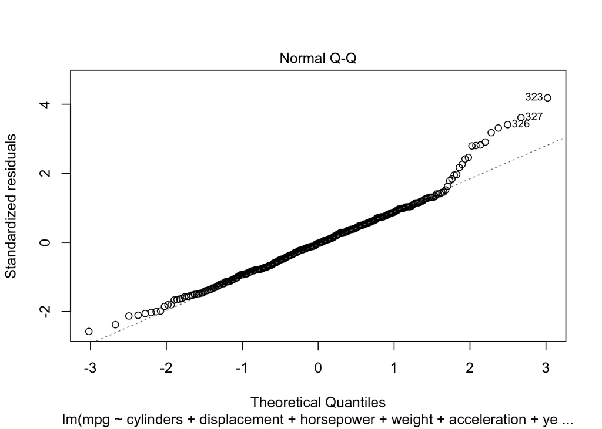

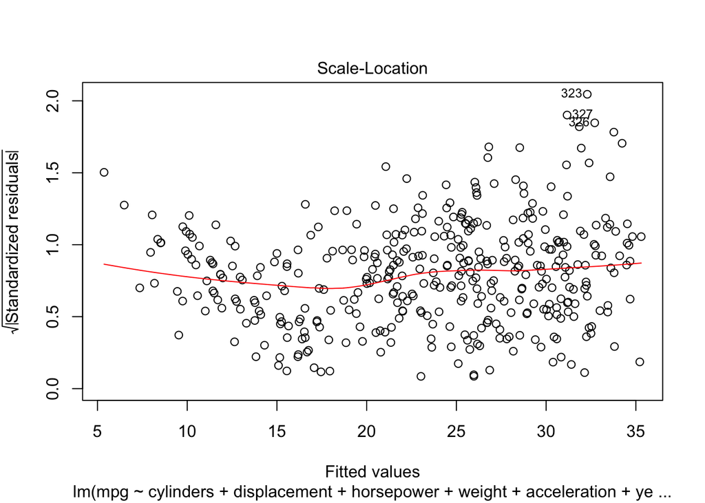

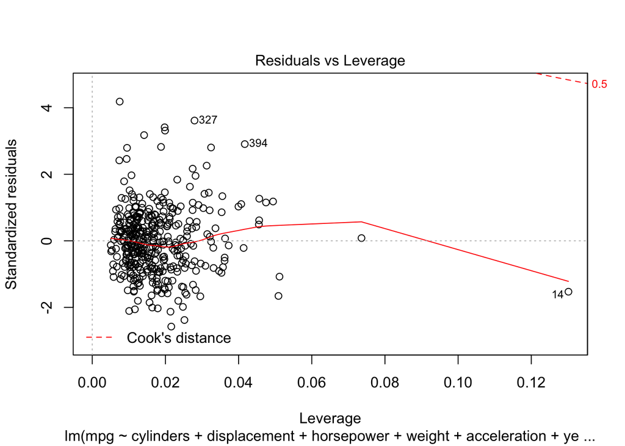

```r
#diagnostic plots of linear reg fit
plot(rs)
```

```r
#residual plots -- outliers?

#leverage plot -- obs w/high leverage?
```

#### Part e

#### Part f

### Question 13

#### Part a

#### Part b

#### Part c

#### Part d

#### Part e

#### Part f

#### Part g

## (Regularization and Cross-validation) section 6.8

### Question 9

see section 6.6 lab2 for step-by-step

#### Part a

#### Part b

#### Part c

#### Part d

## (Clustering and PCA) section 10.7

### Question 10

see section 10.5.1 R tutorial lab 2 for walk-through of clustering, section 10.4 R tutorial lab 1 for PCA

## (Cross-validation) section 5.4

### Question 8(a-e)

see R tuts 5.3.1, 5.3.2, 5.3,3

## (CART and Random Forests) section 8.4

### Question 8

See R tutorial (Lab 2: Fitting Regression Trees) in section 8.3.2 and (Lab 3: Bagging and Random )

## (SVM) section 9.7

### Question 4

See R tutorials in sections 9.6.1 and section 9.6.2 for support vector classifier/machine. For Matlab users, refer to documentation for svmtrain.